# SynSitesRandomization

# Do the same analysis for the non synonymous sites

```r
freqPatTsNonSyn<-freqPatTs[,OverviewDF$TypeOfSite=="nonsyn"]
consensusBNonSyn<-consensusB[OverviewDF$TypeOfSite=="nonsyn"]
AsitesNonSyn<-which(consensusBNonSyn=="a")
CsitesNonSyn<-which(consensusBNonSyn=="c")
GsitesNonSyn<-which(consensusBNonSyn=="g")
TsitesNonSyn<-which(consensusBNonSyn=="t")

ListOfVarsNonSyn<-c()
ListOfNumSites0Freq<-c()
#switch A sites

for (j in 1:100){
  #  if (j %% 10 == 0 ) print (j)
freqPatTsRandomNonSyn<-freqPatTsNonSyn

for (patrow in 1:length(freqPatTs[,1])){
freqPatTsRandomNonSyn[patrow,sample(AsitesNonSyn)]<-freqPatTsNonSyn[patrow,AsitesNonSyn]
freqPatTsRandomNonSyn[patrow,sample(CsitesNonSyn)]<-freqPatTsNonSyn[patrow,CsitesNonSyn]
freqPatTsRandomNonSyn[patrow,sample(GsitesNonSyn)]<-freqPatTsNonSyn[patrow,GsitesNonSyn]
freqPatTsRandomNonSyn[patrow,sample(TsitesNonSyn)]<-freqPatTsNonSyn[patrow,TsitesNonSyn]
}

ListOfNumSites0Freq<-c(ListOfNumSites0Freq,length(which(apply(freqPatTsRandomNonSyn, 2 , mean, na.rm=TRUE)==0)))
ListOfVarsNonSyn<-c(ListOfVarsNonSyn, var(apply(freqPatTsRandomNonSyn, 2 , mean, na.rm=TRUE)))
}
```

Show the distribution of variances form the randomized data and compare with the value of the ofiginal dataset. It looks very different!

```r
#hist(ListOfVars,breaks=20,xlim=c(8*10^-6,2*10^-5), main="Histogram of variances vs observed variance")
## new settings with version 2 adapted with a threshold
min(ListOfVarsNonSyn);max(ListOfVarsNonSyn)
```

```
## [1] 5.47278e-06
```

```
## [1] 6.596314e-06
```

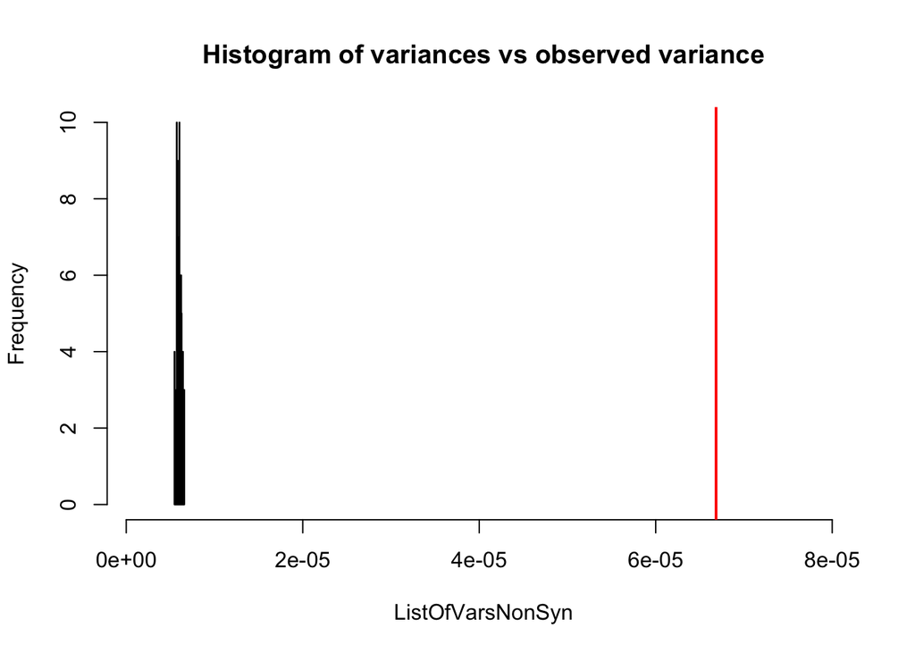

```r
hist(ListOfVarsNonSyn,breaks=20,xlim=c(1*10^-6,8*10^-5), main="Histogram of variances vs observed variance")
abline(v=var(apply(freqPatTsNonSyn, 2 , mean, na.rm=TRUE)),col=2,lwd=2)
```

Show the distribution of the means for one randome dataset and the original data. One can see that the randomized data have much fewer 0s and fewer high values.

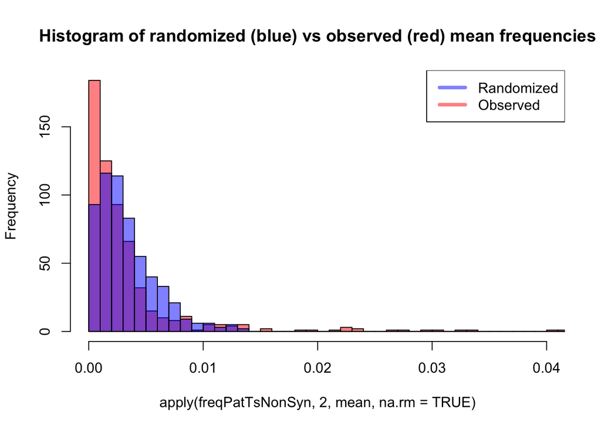

```r
colMeansRandomNonSyn<-apply(freqPatTsRandomNonSyn, 2 , mean, na.rm=TRUE)
colMeansNonSyn<-apply(freqPatTsNonSyn, 2 , mean, na.rm=TRUE)
par(mfrow=c(1,1))
hist(apply(freqPatTsNonSyn, 2 , mean, na.rm=TRUE),breaks=seq(0,0.2,by=0.001),xlim=c(0,0.04),
     #ylim=c(0,40),
     col=rgb(1,0,0,0.5),main="Histogram of randomized (blue) vs observed (red) mean frequencies")
hist(colMeansRandomNonSyn,breaks=seq(0,0.1,by=0.001),xlim=c(0,0.04),ylim=c(0,40),add=T,col=rgb(0,0,1,0.5))
legend("topright", c('Randomized','Observed'), lwd=4, col=c(rgb(0,0,1,0.5), rgb(1,0,0,0.5)))
```

Just to be sure, I want to check that the non-syn sites have lower frequencies than the syn sites and also the stop sites have lower frequencies than the non-syn sites. Not entirely sure what is the best way to do this.

```r
ks.test(colMeansSyn,colMeansNonSyn,alternative="less")
```

```
##
##  Two-sample Kolmogorov-Smirnov test
##
## data:  colMeansSyn and colMeansNonSyn
## D^- = 0.66609, p-value < 2.2e-16
## alternative hypothesis: the CDF of x lies below that of y
```

```r
freqPatTsStop<-freqPatTs[,OverviewDF$TypeOfSite=="stop"]
colMeansStop<-apply(freqPatTsStop, 2 , mean, na.rm=TRUE)

ks.test(colMeansNonSyn,colMeansStop,alternative="less")
```

```
##
##  Two-sample Kolmogorov-Smirnov test
##
## data:  colMeansNonSyn and colMeansStop
## D^- = 0.95904, p-value < 2.2e-16
## alternative hypothesis: the CDF of x lies below that of y
```

Find out how many non syn sites have 0 frequency and how many we’d expect to have 0 freq.

```r
length(which(colMeansNonSyn==0))
```

```
## [1] 24
```

```r
length(which(colMeansRandomNonSyn==0))
```

```
## [1] 8
```

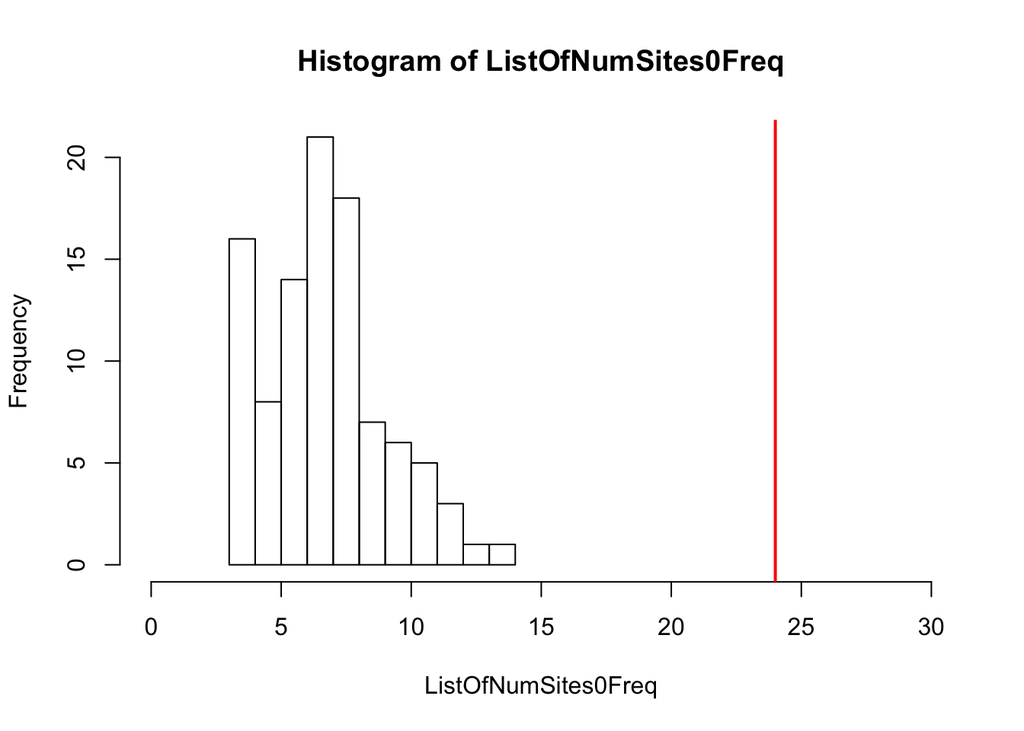

```r
hist(ListOfNumSites0Freq,xlim=c(0,30))
abline(v=length(which(colMeansNonSyn==0)),lwd=2,col=2)
```

Where are the non-syn sites with 0 frequency?

OK, let’s redo this with the new data!

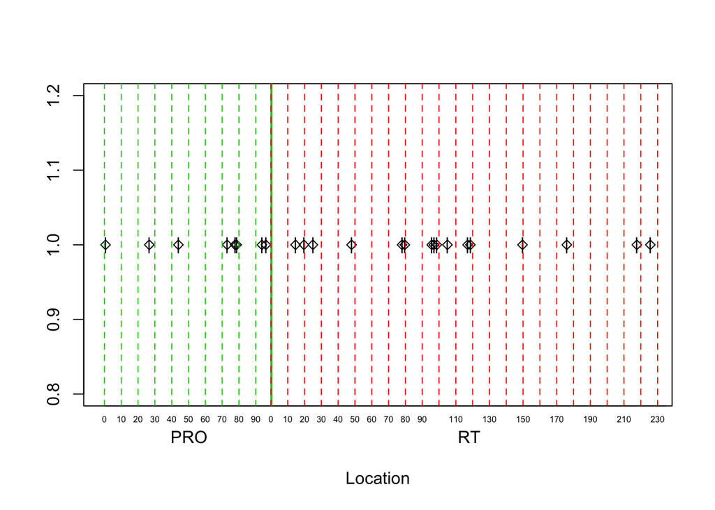

```r
plot(which(OverviewDF$TypeOfSite=="nonsyn")[which(colMeansNonSyn==0)],rep(1,length(which(colMeansNonSyn==0))),xaxt="n",xlab = "Location",ylab="",ylim=c(0.8,1.2),pch=23)
points(which(OverviewDF$TypeOfSite=="nonsyn")[which(colMeansNonSyn==0)],rep(1,length(which(colMeansNonSyn==0))),pch="|",cex=1)
axis(1, at=c(0,150,297,650,1000), labels=c("","PRO","","RT",""),tck=0)
abline(v=297,col=3,lwd=2)
abline(v=seq(-1,297,by=30),col=3,lwd=1,lty=2)
abline(v=seq(296,1000,by=30),col=2,lwd=1,lty=2)
axis(1, at=seq(-1,297,by=30), labels=seq(0,99,by=10),cex.axis=.5,tck=0,line=-1,lty=0)
axis(1, at=seq(296,1000,by=30), labels=seq(0,234,by=10),cex.axis=.5,tck=0,line=-1,lty=0)
```